# Teaching Data Science to Students in Biology using R, RStudio and Learnr: Analysis of Three years Data

# Abstract

**This is the original abstract that should be reworked according to final content of the manuscript.**

The courses in biostatistics in biology at the University of Mons, Belgium, were completely refactored in 2018 into data science courses (see http://bds.sciviews.org). The content is expanded beyond statistics to include computing tools, version management, reproducible analyses, critical thinking and open data. Flipped classroom approach is used. Students learn with the online material and they apply the concepts on individual and group projects using a preconfigured virtual machine with R and RStudio. Activities (H5P, learnr or Shiny applications) are recorded in a MongoDB database (300,000+ events for 180+ students and 2,000+ GitHub repositories at https://github.com/BioDataScience-Course). The analysis of these data reveals several trends. (1) There is a relatively long lag period required for the students to get used to the computing environment, the teaching method and the data science in general. (2) Implication is very high, with more than 85% of the students that complete all the activities and got good to excellent assessment. (3) There is a gap between students’ own perception of their skills achievements and their assessment results: they tend to underestimate their progress. (4) During COVID-19 pandemic lockdown, the intensity of the activities largely decreased during two weeks before returning to previous level, but for 3/4 of the students only. The remaining fraction never caught up. We hypothesize that the technical requirements or the lack of motivation during the lockdown were detrimental to roughly one student over ten, despite all the efforts the University deployed to reduce the social fracture.

# Introduction

In a context where there is an exponentially growing mass of data (Marx 2013), a reproducibility crisis in Science (Baker 2016), and a progressive adoption of Open Science practices (Banks et al. 2019), statistics were broaden to a larger discipline called Data Science. For the Data Science association, “the Data Science means the scientific study of the creation, validation and transformation of data to create meaning” (http://www.datascienceassn.org/code-of-conduct.html). These changes also led to the emergence of data science programs in universities and higher schools (Donoho 2017; Çetinkaya-Rundel and Ellison 2021). One example is the Harvard Data Science initiative (https://datascience.harvard.edu/about) initiated in 2017. With a broader approach, comes also a broaden public. The data science courses are not just limited to computer scientists, mathematicians or statisticians, but also welcome students in humanities, social sciences, and natural sciences (for instance, the data science training at Duke University (Çetinkaya-Rundel and Ellison 2021)). Main focus of such courses is for students to develop the ability to deal with “real” datasets in all their complexities and to realize reproducible analyses to interpret these data in the light of knowledge in their field of expertise.

The data transformation part of the job is a challenge for students with a poor or no background at all in computing. Students that are not used to deal with computer languages enter in a foreign world and have to deal with many exotic concepts, techniques and tools. This is the same for the analysis of these data when students have no background in mathematics or statistics. It generates anxiety (see for instance (Onwuegbuzie and Wilson 2003), for students in biology). The course must be organized in a way that such students progress by little steps in order to avoid exposition to much intimidating concepts and tools at once. Hence, a student in computing science already masters one or more computing languages, is acquainted with version control systems, with databases and with the way data are represented in a computer. A student in mathematics or statistics is familiar with various concept that underpin the techniques to analyse the data. On the other hand, students in biology, medicine, psychology, social sciences, economics, … have very different *a priori* knowledges. Version control systems like git, and their internet hosting counterparts like GitHub, Gitlab or Bitbucket also make part of the tools that data science course teach and use (Fiksel et al. 2019; Hsing and Gennarelli 2019). Presentation of the results and the use of documents formats that dissociate content from presentation, namely LaTeX, Jupyter Notebook, or R Markdown also contribute to the large number of potentially new tools students have to learn (Baumer et al. 2014).

Suitable computer hardware and software environments are required in the practical sessions of the courses. Different approaches range from inline software (RStudio Cloud (https://rstudio.cloud/), Chromebook data science (http://jhudatascience.org/chromebookdatascience/)) to local installation on the Student’s computers. The former requires an infrastructure to run the software on a server, nad that software is only accessible to the students during the course. The later raises problems of license for proprietary software, but also installation and configuration issues. An intermediary solution uses preconfigured virtual machines, or containers (e.g., Docker) (Çetinkaya-Rundel and Rundel 2018 ; Boettiger 2015). Such a solution is the most flexible because it can be deployed almost anywhere (in the computer lab, at home, using a laptop, …). To fix theoretical concepts through applied exercises is a key aspect of learning data science (Larwin and Larwin 2011). Correct choice of software is critical and exposing students early with the tools they are most susceptible to use later in their work is desirable. This was highlighted by (Auker and Barthelmess 2020) for instance, for the analysis of ecological data.

These data science courses pose several challenges to pedagogy because various, numerous and unfamiliar concepts must be acquired by a population of potentially very diverse students. Learning objectives span a large range of cognitive abilities (Krathwohl 2002). [We need to develop here things like flipped classroom, continuous evaluation, pedagogy by projects, and inclusive pedagogy]. The flipped classroom approach allows students to be active in their learning, which has the benefit of improving student outcomes (Freeman et al. 2014).

Recently, data science is also used to analyze the effect of different pedagogical practices on the outcome of these courses [Estrellado et al. (2020); second ref to add]. A vast amount of data can be collected on students activities, and the analysis of these data allows to compare the impact of different pedagogical approaches, or to quantify and document the impact of changes in the courses.

At the University of Mons in Belgium, we have started to rework our biostatistics courses in the biology curriculum in 2018. A series of Data Science courses were introduced, both for our undergraduate and graduate students. These courses are inspired from precursor initiatives cited here above. The goal of these courses is to form biological data scientists capable to extract meaningful information from raw biological data, and to do so in a reproducible way, with correct application of statistical tools and an adequate critical mindset. A preconfigured VirtualBox virtual machine with R, RStudio, Rmarkdown, git, and a series of R packages preinstalled is used (url sciviews box?) as a very flexible way to deploy the same software environment both on the university computers and on student’s own laptops.

As our course were completely reworked, we also decided to use flipped classroom and progressive adoption of suitable pedagogical practices with a cyclical approach that consists in stating goals, building pedagogical material with a large emphasis on numerical tools and collection of student’s activities, and finally, analysis of the data collected. Conclusions of these analyses initiate another cycle the following academic year with refined goals and pedagogical materials and techniques. Here, we present the main results spanning on three successive academic years from 2018 to 2021, including two particular periods where distance learning was forced due to COVID pandemic lockdown.

# Methods

The course materials are available online (https://wp.sciviews.org) and are centralized in a Wordpress site. Students have to login with their GitHub account and their academic data are collected from the UMONS Moodle server. The courses are break down into modules that amount roughly to 15h of work each in total. There are two sessions of 2h and 4h in the classroom (outside of lockdown periods, of course). Main activities in the class are actual data analysis (projects), answering student questions, and very sort lectures of 1/4h on selected topics. Students propose and vote for the topics to be covered during these short lectures. Finally, we encourage students to help each other and to explain what they understand to their colleagues. Indeed, students’ questions may be redirected to other students that have already mastered the topic by the educators. On the other hand, teachers rarely answer questions directly. When it is possible, they rather propose new tracks or ideas to investigate in order to find the solution by oneself. Students that have finished the work before the others are encouraged to help their colleagues too.

Regarding the timing, one module it taught every second week so that students have enough time to prepare the material at home and then, to finalize their projects before the next module. Since a term is 14 weeks, we do not teach more than six modules in a course unit to avoid compacting them in time at a faster pace than one module every second week.

All student activities in H5P exercises for their auto-evaluation, and in learnr tutorials to transition smoothly from the theory to the practice are recorded in the MongoDB database. The learnitdown R package (https://www.sciviews.org/learnitdown/) provides the functions required to manage user login, user identification and activity tracking in the interactive material.

In distance learning, support to the students was done via email and Discord. At the end, all messages that were exchanged are collected together into text files. These files are scraped using R code to create a table with key information (basically, who, when, and what) for each message. Surveys are periodically conducted during lessons by means of Wooclap questionnaires (see, for instance, the Nasa-LTX questionnaire analysis in the results section). Wooclap allows to export data into Excel files. These data are then converted into a table in our database.

The course material is organized in a way that favour autonomy and auto-evaluation (direct feedback in the exercises, hints and retry button in case of wrong answer). Activities span into a sequence of exercises of increasing difficulty, ranging from Level 1 to level 4. Table 1 summarizes main characteristics of the exercises according to the level.

| Level | Description | Type |
| --- | --- | --- |
| L1 | Short exercise directly integrated in the course and with direct feedback for auto-evaluation | h5p |
| L2 | Guided exercise with contextual feedback within a short tutorial | learnr |
| L3 | Individual and guided data analysis | individual project |
| L4 | More complex and free data analysis and reporting (group of 2 or 4 students) | group project |

The NASA-LTX questionnaire is composed of six questions on a Likert scale to quantify the perceived workload to complete a task (Hart and Staveland 1988). The questions concern mental load, physical load, time pressure, expected success, effort required, and frustration experienced during the accomplishment of the task. The average value for the six questions constitutes a Raw Task Load indeX (RTLX) (Byers, Bittner, and Hill 1989) that we use to quantify how students perceive the workload of a given task.

# Results

Liste des idées développées dans cette section :

- exam versus project 2018 et 2019 => elimination de l’examen
- profiles analyse SOM => sous-groupes + analyse des groupes y compris comparaison avec les grades
- temporel présentiel -> distanciel
- learnrs (+ perception) -> apprentissage sur le très long terme (> 1 ou deux quadris)

```r
# Tab of number of users and number of exercices by type ----------------------
# users
users %>.%
  filter(., institution == "UMONS" & term == "Q1" & state == "regular") %>.%
  group_by(., course) %>.%
  summarise(., user = n()) %>.%
  ungroup(.) %>.%
  filter(., course != "D")-> us_tab

# learnr
learnr %>.%
  filter(., !app %in% c("A06Lb_recombinaison", "A99La_avis", "B00La_rappel", "B99La_avis","C99La_avis") & !is.na(label)) %>.%
  mutate(., course = substr(app,1,1),
    app_label = paste0(app, label)) %>.%
  filter(., course %in% c("A", "B", "C")) %>.%
  group_by(., course) %>.%
  summarise(., app = length(unique(app)), questions = length(unique(app_label))) -> learnr_tab

# projects
projects %>.%
  filter(., type %in% c("ind. github", "group github") & course != "D") %>.%
  group_by(., course, type) %>.%
  count(.) %>.%
  pivot_wider(., names_from = "type", values_from = "n") %>.%
  ungroup(.) %>.%
  select(., course, `ind. github`, `group github`)-> projects_tab

# tab number of exercices by type ---
assessments %>.%
  filter(., type == "h5p") %>.%
  mutate(.,
    app_type = paste0(app, "_" ,'type'),
    course = substr(app, start = 1, stop = 1),
    ) %>.%
  group_by(., course) %>.%
  summarise(., h5p = length(unique(app_type))) -> h5P_tab

us_tab %>.%
  mutate(., module = c(12, 8, 6)) %>.%
  left_join(., h5P_tab) %>.%
  left_join(., mutate(learnr_tab, learnr = paste0(app, " (", questions, ")"), .keep = "unused")) %>.%
  left_join(., projects_tab) %>.%
  knitr::kable(., caption = "Number of users, modules, exercises with h5p, learnr tutorial,individual project and group project by course. The number of quesion by learnr tutorial are in the parentheses.")
```

Number of users, modules, exercises with h5p, learnr tutorial,individual project and group project by course. The number of quesion by learnr tutorial are in the parentheses.

| course | user | module | h5p | learnr | ind. github | group github |
| --- | --- | --- | --- | --- | --- | --- |
| A | 42 | 12 | 59 | 24 (211) | 10 | 4 |
| B | 40 | 8 | 29 | 11 (108) | 12 | 2 |
| C | 25 | 6 | 19 | 7 (37) | 7 | 1 |

## Exams versus project

```r
assessments18 %>.%
  #select(., -coral_growth, result = biometry) %>.%
  mutate(., result = (biometry+coral_growth)/2, acad_year = "2018-2019") -> assess_result18

q1_18_regular <- left_join(rename(assess_result18, icourse = course), courses18) %>.%
  filter(., user %in% users18$user[users18$institution == "UMONS" & users18$term == "Q1" & users18$state == "regular"])

assessments19 %>.%
  group_by(., course, evaluation, github_project, project, user) %>.%
  summarise(., result = round(sum(score*weight),4)) %>.%
  filter(., evaluation == "Q1") %>.%
  left_join(exam19, .) %>.%
  replace_na(., list(result = 0)) %>.%
  mutate(., acad_year = "2019-2020")-> assess_result19

q1_19_regular <- left_join(rename(assess_result19, icourse = course), courses19) %>.%
  filter(., user %in% users19$user[users19$institution == "UMONS" & users19$term == "Q1" & users19$state == "regular"])

q1 <- bind_rows(
  select(q1_18_regular, user, acad_year, course, result, exam),
  select(q1_19_regular, user, acad_year, course, result, exam)
  )
#table(q1$link) /nrow(q1)
```

Until the first four months of the 2019-2020 academic year, students’ grades were based on the completion of a project and a more conventional examination during the examination period. The projects are assessed using a grading grid since the 2019-2020 academic year.

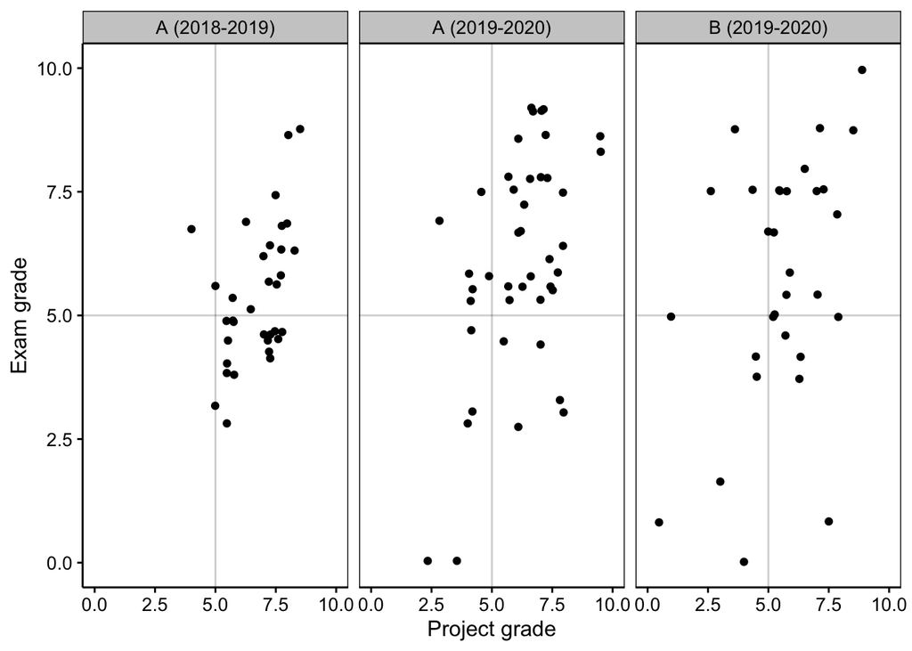

```r
q1 %>.%
  mutate(., course_year = paste0(course, " (",acad_year,")")) %>.%
  chart(., exam ~ result | course_year) +
  geom_vline(xintercept = 5, alpha = 0.2) +
  geom_hline(yintercept = 5, alpha = 0.2) +
  geom_jitter(alpha = 1, width = 0.05, height = 0.05, show.legend = FALSE) +
  ylim(c(0,10)) +
  xlim(c(0,10)) +
  labs(y = "Exam grade", x = "Project grade")
```

The comparison of the marks obtained between the project and the exam mark shows a strong disparity between these two types of evaluation.

Despite an examination that includes theoretical and practical questions, this type of assessment does not assess a student’s ability to correctly process and analyse biological data.

Following these results and the monitoring of more precise exercises, the examination is definitively abandoned for the 2020-2021 academic year to be replaced by a continuous assessment.

## Transition between face-to-face and distance learning

Due to Covid-19 lockdown periods, distance learning had to be adopted abruptly. We analyze the activity and support data collected during academic years 2019-2020 and 2020-2021 to assess the impact of this transition on the progression of the students.

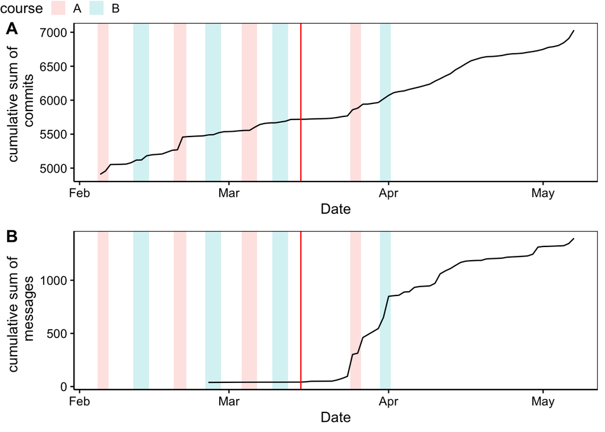

```r
lessons19 %>.%
  filter(., !topic %in% c("extra_session", "debriefing_S-BIOG-006", "debriefing_S-BIOG-015")) %>.%
  filter(., icourse %in% c("S-BIOG-027", "S-BIOG-061")) %>.%
  group_by(., course, module) %>.%
  summarise(., start = min(start), end = max(end)) -> lessons_red19

log19 %>.%
  distinct(., commit, .keep_all = TRUE) %>.%
  filter(., is.na(from)) %>.%
  mutate(., date_round = lubridate::round_date(date, "day")) %>.%
  group_by(., date_round) %>.%
  count(.) %>.%
  ungroup(.) %>.%
  mutate(., cumul_commit = cumsum(n)) %>.%
  filter(., date_round >= courses19$start[courses19$icourse == "S-BIOG-027"] & date_round <= courses19$end[courses19$icourse == "S-BIOG-027"])-> log_temp19

support19 %>.%
  mutate(., date_round = lubridate::round_date(date, "day")) %>.%
  group_by(., date_round) %>.%
  count(.) %>.%
  ungroup(.) %>.%
  mutate(., cumul_message = cumsum(n))  %>.%
  filter(., date_round >= courses19$start[courses19$icourse == "S-BIOG-027"] & date_round <= courses19$end[courses19$icourse == "S-BIOG-027"]) -> sup_temp19

plog19 <- ggplot() +
  geom_rect(data = lessons_red19, aes(xmin = start, xmax = end , ymin = -Inf,  ymax = Inf, fill = course), alpha = 0.2) +
  geom_line(data = log_temp19, aes(y = cumul_commit, x = date_round)) +
  geom_vline(xintercept = as.POSIXct("2020-03-15"), color = "red") +
  theme_sciviews() +
  labs(x = "Date", y = "cumulative sum of \n commits")

psup19 <- ggplot() +
  geom_rect(data = lessons_red19, aes(xmin = start, xmax = end , ymin = -Inf,  ymax = Inf, fill = course), alpha = 0.2) +
  geom_line(data = sup_temp19, aes(y = cumul_message, x = date_round)) +
  geom_vline(xintercept = as.POSIXct("2020-03-15"), color = "red") +
  theme_sciviews() +
  labs(x = "Date", y = "cumulative sum of  \n messages")

combine_charts(list(plog19, psup19), nrow = 2, common.legend = TRUE)
```

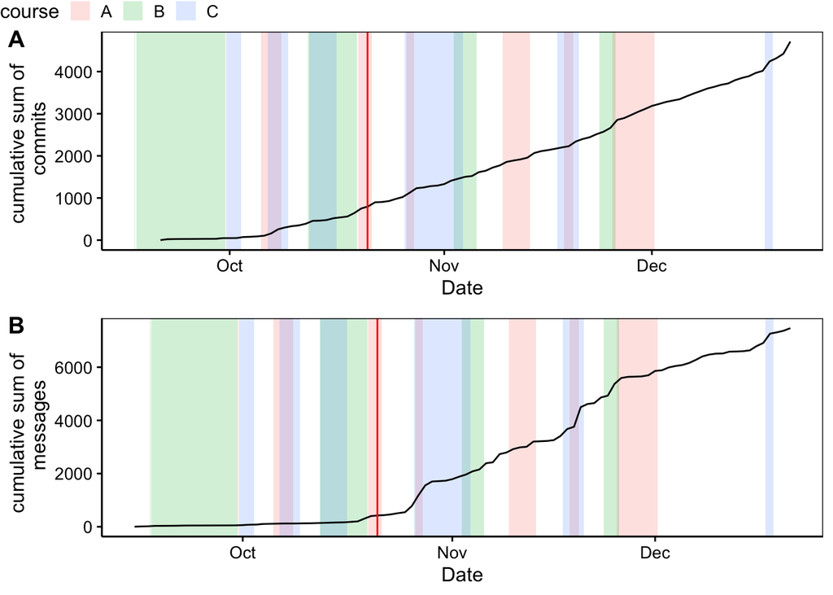

cumulative sums of commit and message over time in first term of 2020-2021. The period of each module per course is represented by area.

```r
lessons %>.%
  filter(., !topic %in% c("extra_session", "debriefing_S-BIOG-006", "debriefing_S-BIOG-015")) %>.%
  filter(., icourse %in% c("S-BIOG-006", "S-BIOG-015", "S-BIOG-025")) %>.%
  group_by(., course, module) %>.%
  summarise(., start = min(start), end = max(end)) -> lessons_red

log %>.%
  distinct(., commit, .keep_all = TRUE) %>.%
  filter(., is.na(from)) %>.%
  mutate(., date_round = lubridate::round_date(date, "day")) %>.%
  group_by(., date_round) %>.%
  count(.) %>.%
  ungroup(.) %>.%
  mutate(., cumul_commit = cumsum(n))%>.%
  filter(., date_round >= courses$start[courses$icourse == "S-BIOG-006"] & date_round <= courses$end[courses$icourse == "S-BIOG-006"])-> log_temp

support %>.%
  mutate(., date_round = lubridate::round_date(date, "day")) %>.%
  group_by(., date_round) %>.%
  count(.) %>.%
  ungroup(.) %>.%
  mutate(., cumul_message = cumsum(n))  %>.%
  filter(., date_round >= courses$start[courses$icourse == "S-BIOG-006"] & date_round <= courses$end[courses$icourse == "S-BIOG-006"]) -> sup_temp

plog <- ggplot() +
  geom_rect(data = lessons_red, aes(xmin = start, xmax = end , ymin = -Inf,  ymax = Inf, fill = course), alpha = 0.2) +
  geom_line(data = log_temp, aes(y = cumul_commit, x = date_round)) +
  geom_vline(xintercept = as.POSIXct("2020-10-21"), color = "red") +
  theme_sciviews() +
  labs(x = "Date", y = "cumulative sum of \n commits")

psup <- ggplot() +
  geom_rect(data = lessons_red, aes(xmin = start, xmax = end , ymin = -Inf,  ymax = Inf, fill = course), alpha = 0.2) +
  geom_line(data = sup_temp, aes(y = cumul_message, x = date_round)) +
  geom_vline(xintercept = as.POSIXct("2020-10-21"), color = "red") +
  theme_sciviews() +
  labs(x = "Date", y = "cumulative sum of  \n messages")

combine_charts(list(plog, psup), nrow = 2, common.legend = TRUE)
```

During the second lockdown, the students’ work remained constant (graph A) and the remote communication tools were logically more used (graph B). The students did not need a new adaptation phase as observed during the first lockdown.

## Learnr tutorials perceived cognitive workload

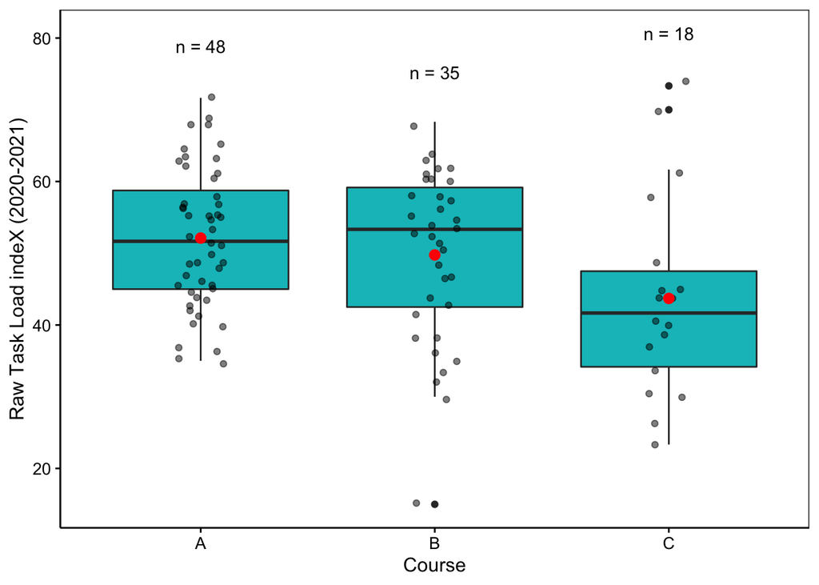

```r
c("A99Wa_perception", "B99Wa_perception", "C99Wb_perception:perception") %>%
  purrr::map_dfr(learnr_feeling, df = wo, label = "Q4") %>.%
  mutate(., course = substr(app, start = 1, stop = 1)) -> learnr_workload

learnr_workload %>.%
  pivot_longer(.,cols = c(mental, physical, time_pressure, performance, effort, frustration),
  names_to = "category", values_to = "grade")  %>.%
  left_join(., dplyr::distinct(courses, course,name), by = "course")-> workload

workload %>.%
  group_by(., user, app, course) %>.%
  #filter(., user != "ECAYEO033") %>.%
  summarise(., rtlx = 10*mean(grade)) -> workload_rtlx

set.seed(222)
chart(workload_rtlx, rtlx ~ course) +
  geom_boxplot(fill = "#00BFC4") +
  geom_jitter(alpha = 0.5, width = 0.1) +
  labs(y = "RTLX", x = "Course") +
  stat_summary(fun.y="mean", color = "red")+
  stat_summary(fun.data = n_fun, geom = "text", hjust = 0.5) +
  labs( y = "Raw Task Load indeX (2020-2021)")
```

The difficulty of the course, and thus, of the exercises in the tutorials increase from one course to the other. However, we do not observe an increase in the RTLX index. On the contrary, it is significantly lower for course C than for course A (Tukey HSD, p-value = 0.023). The cognitive load perceived by the students diminishes. This may be a consequence of a more fluent R coding and the better mastering of all the software tools the students have to use.

```r
workload_rtlx %>.%
  mutate(., course = as.factor(course)) -> workload_rtlx

#kruskal.test(data = workload_rtlx, rtlx ~ course)
#summary(kw_comp. <- nparcomp::nparcomp(data = workload_rtlx, rtlx ~ course))

anova. <- lm(data = workload_rtlx, rtlx ~ course)
anova(anova.)
```

```
## Analysis of Variance Table
##
## Response: rtlx
##           Df  Sum Sq Mean Sq F value  Pr(>F)
## course     2   926.9  463.47  3.5883 0.03134 *
## Residuals 98 12658.0  129.16
## ---
## Signif. codes:  0 '***' 0.001 '**' 0.01 '*' 0.05 '.' 0.1 ' ' 1
```

```r
#bartlett.test(data = workload_rtlx, rtlx ~ course)
#plot(anova., which = 2)

summary(anovaComp. <- confint(multcomp::glht(anova.,
  linfct = multcomp::mcp(course = "Tukey"))))
```

```
##
##   Simultaneous Tests for General Linear Hypotheses
##
## Multiple Comparisons of Means: Tukey Contrasts
##
##
## Fit: lm(formula = rtlx ~ course, data = workload_rtlx)
##
## Linear Hypotheses:
##            Estimate Std. Error t value Pr(>|t|)
## A - B == 0    2.356      2.526   0.933   0.6183
## C - B == 0   -6.058      3.296  -1.838   0.1607
## C - A == 0   -8.414      3.141  -2.679   0.0229 *
## ---
## Signif. codes:  0 '***' 0.001 '**' 0.01 '*' 0.05 '.' 0.1 ' ' 1
## (Adjusted p values reported -- single-step method)
```

# Discussion

# Conclusions

- Exam classique évalue mal la capacité d’evaluer des données biologiques par eux même
- Les biologistes non expert de l’informatique est une challenge vu le nombre important de notions a apprendre utilisation d’un ordi, gestion de projet, statistique. Il faut décomposer ces notions en petites étapes successives si nous ne voulons pas les perdre rapidement. Notre approche en 3 cours étalés sur 5 quadrimestres successifs et étalés sur 3 années semblent correspondre à un bon timing pour ce type d’étudiant qui, au départ, n’a aucune notion de statistique, et très peu de connaissance des outils des logiciels couramment utilisées par le scientifique des données.
- Néanmoins, malgré leur habituation progressive, ces logiciels restent vus comme pointu et diffficile d’utilisation (SUS) [à voir si on met cela dans l’article: on a déjà beaucoup ! => réserver cela pour un autre article l’annéde prochaine peut-être ?].
- l’evaluation continue et l’analyse de projet via des grilles critérié semble une approche intéressante pour juger de la capacité des étudiant à bosser [on a pas développé cela au final, il me semble].
- la catégorisation des étudiants en différents profils d’apprenants ayant adopté des stratégies très contrastées démontre une grande diversité des apprenants, même à l’intérieur d’un groupe a priori homogène (n,ous ne nous trouvons pas ici dans une grande classe qui regrouperait des étudiants d’horizons très différents comme les cours d’introduction à la science des données tels que pratiques dans certaines grandes universités américaines). Ceci est un premier pas vers une pédagogie différencié et plus inclusive qui s’avèrent être des éléments importants ici.

# References

Auker, Linda A., and Erika L. Barthelmess. 2020. “Teaching R in the undergraduate ecology classroom: approaches, lessons learned, and recommendations.” *Ecosphere* 11 (4): e03060. https://doi.org/https://doi.org/10.1002/ecs2.3060.

Baker, Monya. 2016. “1,500 Scientists Lift the Lid on Reproducibility.” *Nature* 533 (7604): 452–54. https://doi.org/10.1038/533452a.

Banks, George C., James G. Field, Frederick L. Oswald, Ernest H. O’Boyle, Ronald S. Landis, Deborah E. Rupp, and Steven G. Rogelberg. 2019. “Answers to 18 Questions About Open Science Practices.” *Journal of Business and Psychology* 34 (3): 257–70. https://doi.org/10.1007/s10869-018-9547-8.

Baumer, Ben, Mine Cetinkaya-Rundel, Andrew Bray, Linda Loi, and Nicholas J. Horton. 2014. “R Markdown: Integrating A Reproducible Analysis Tool into Introductory Statistics.” *Technology Innovations in Statistics Education* 8 (1). https://doi.org/10.5070/t581020118.

Boettiger, Carl. 2015. “An Introduction to Docker for Reproducible Research.” *SIGOPS Oper. Syst. Rev.* 49 (1): 71–79. https://doi.org/10.1145/2723872.2723882.

Byers, J C, A Bittner, and S Hill. 1989. “Traditional and raw task load index (TLX) correlations: Are paired comparisons necessary? In A.” In.

Çetinkaya-Rundel, Mine, and Victoria Ellison. 2021. “A Fresh Look at Introductory Data Science.” *Journal of Statistics Education* 0 (0): 1–27. https://doi.org/10.1080/10691898.2020.1804497.

Çetinkaya-Rundel, Mine, and Colin Rundel. 2018. “Infrastructure and Tools for Teaching Computing Throughout the Statistical Curriculum.” *American Statistician* 72 (1): 58–65. https://doi.org/10.1080/00031305.2017.1397549.

Donoho, David. 2017. “50 Years of Data Science.” *Journal of Computational and Graphical Statistics* 26 (4): 745–66. https://doi.org/10.1080/10618600.2017.1384734.

Estrellado, Ryan A., Emily A. Bovee, Jesse Mostipak, Joshua M. Rosenberg, and Isabella C. Velásquez. 2020. *Data science in education using R*. London, England: Routledge. https://datascienceineducation.com/.

Fiksel, Jacob, Leah R. Jager, Johannna S. Johanna S Hardin, and Margaret A. Taub. 2019. “Using GitHub Classroom To Teach Statistics.” *Journal of Statistics Education* 27 (2): 110–19. https://doi.org/10.1080/10691898.2019.1617089.

Freeman, Scott, Sarah L. Eddy, Miles McDonough, Michelle K. Smith, Nnadozie Okoroafor, Hannah Jordt, and Mary Pat Wenderoth. 2014. “Active learning increases student performance in science, engineering, and mathematics.” *Proceedings of the National Academy of Sciences* 111 (23): 8410–15. https://doi.org/10.1073/PNAS.1319030111.

Hart, Sandra G., and Lowell E. Staveland. 1988. “Development of NASA-TLX (Task Load Index): Results of Empirical and Theoretical Research.” *Advances in Psychology* 52 (C): 139–83. https://doi.org/10.1016/S0166-4115(08)62386-9.

Hsing, Courtney, and Vanessa Gennarelli. 2019. “Using GitHub in the Classroom Predicts Student Learning Outcomes and Classroom Experiences: Findings from a Survey of Students and Teachers.” In *Proceedings of the 50th ACM Technical Symposium on Computer Science Education*, 672–78. SIGCSE ’19. New York, NY, USA: Association for Computing Machinery. https://doi.org/10.1145/3287324.3287460.

Krathwohl, David R. 2002. “A Revision of Bloom’ s Taxonomy: An otherview.” *Theory Into Practice* 41 (4): 212–18. https://doi.org/10.1207/s15430421tip4104.

Larwin, Karen, and David Larwin. 2011. “A meta-analysis examining the impact of computer-assisted instruction on postsecondary statistics education: 40 years of research.” *Journal of Research on Technology in Education* 43 (3): 253–78. https://doi.org/10.1080/15391523.2011.10782572.

Marx, Vivien. 2013. “The big challenges of big data.” *Nature* 498 (7453): 255–60. https://doi.org/10.1038/498255a.

Onwuegbuzie, Anthony J., and Vicki A. Wilson. 2003. “Statistics Anxiety: Nature, etiology, antecedents, effects, and treatments–a comprehensive review of the literature.” *Teaching in Higher Education* 8 (2): 195–209. https://doi.org/10.1080/1356251032000052447.